# The R Ecosystem at Uplift Education

February 4, 2017

## The Purpose of This Presentation

- Understand how an organization decides to use R, an open source statistical programming language and environment
- Understand the ways an organization uses R (or does not use R), and how that use has evolved over time
- Give some tips based on lessons learned
- Get feedback and thoughts about next steps from users in the audience

## What is Uplift Education?

Uplift Education is a free public charter school network, pre-K to 12, serving 16,000 students at 36 schools on 17 campuses in the Dallas-Fort Worth region.

Uplift's mission is to create and sustain public schools of excellence that empower students to reach their highest potential in college and the global marketplace and that inspire in students a life-long love of learning, achievement, and service in order to positively change their world.

## The Project that Started It

In summer of 2013, Uplift began developing a Student Growth Model

> "A growth model is a collection of definitions, calculations, or rules that summarizes student performance over two or more time points and supports interpretations about students, their classrooms, their educators, or their schools."

> *A Practioner's Guide to Growth Models*

## Uplift Growth Model

- First model was built in Excel with the help of graduate students who had Minitab
- Process involved:
  - Pulling down relevant student data from SQL into a .csv
  - Opening it using Excel
  - Running regressions using the Data Analysis feature
- This process was time intensive and only somewhat scriptable via VBA (we intially wrote VBA scripts to do it)
- This process also made reproducibility difficult, thus slowing iterations of the growth model

## Why R?

- Required an inexpensive and extensible software to run regressions and advanced analytics
- Required a software that we could shape the direction of the capabilities available
- We had some experience with R, and knew that with the large number of packages continually being developed gave us a tremendous amount of flexibility
- We were interested in the idea of *literate programming* *(thanks Donald Knuth!), due to difficulty that we were experiencing transitioning an analysis among our analytics team and explaining our work more broadly within our district

## Why Not Other Options

- Excel did not allow for easy reproducibility of analyses or tracking of changes to our analyses. File size was also an issue (Excel 2010).
- Stata and JMP addressed the limitations of Excel, but were too expensive for our team to use for the long term. We did end up using both of these tools simultaneously for a year (more on this later).
- Python was also an option, but R was was easier to grasp for our team, given we had some statistical programming knowledge.

## Initial Forays:

- Since the growth model was already complete, we decided to start building another model that would predict end of year student performance on the the State of Texas Assessments of Academic Readiness (STAAR) using internal and national benchmark assessments as inputs
- The initial model was built in R, and ended up being how R was first introduced as a tool to Uplift Education.
- R was also meant to replace the Excel based method of creating our growth model.

## The Initial Ask for R to our IT Department

> What is the IT Policy was on downloading software? I want to download three reputable open source software packages (these are often used in academia) in order to support the work I am doing on developing a predictive model of student performance:
1. R: An open source software environment for statistical computing. It is frequently used in academia and offers more functionality than STATA (a pricey statistical software package) and requires less computing power than SAS (which is also prohibitively expensive).
2. R Studio: An open source Integrated Development Environment and user interface (similar to Eclipse) designed for R. It will allow me to debug R code more efficiently.
3. Notepad++: An open source code editor/text editor.

## Predictive Model of Student Performance

```
##
## Call:
## lm(formula = STAARScaleScore ~ MAPFallScore + CA1PercentScore +
##     CA2PercentScore + MAPWinterScore, data = LoadMath3)
##
## Coefficients:
##     (Intercept)     MAPFallScore  CA1PercentScore  CA2PercentScore
##         -10.634            2.285           53.711          182.545
##  MAPWinterScore
##           4.454
```

## Getting others to use R

- I initially started teaching R to the other 5 members of our Data Team by explaining the results of the model, and they found it compelling.
- Everyone was interested enough to install our Statistical Programming Stack:
  - R
  - R Studio
  - Notepad++
- However, the pace of work was a barrier to getting others the time needed to learn R.

## Diversions in JMP and Stata

- In 2014-2015, our growth model was built using JMP. One of our analysts started a Master's program, gaining access to JMP.
- However, predictions were once again built using R.
- In the Spring, the update to these predictions was done using JMP.
- Work was also done in Stata
- R fell by the wayside, and we had inadvertantly created single points of failure within our organization of who could create predictions or growth models, due to the software they were built in.

## Getting back to R

- Our analyst with JMP left Uplift in the Fall of 2015, right after the refresh of the growth model was completed.
- We now had no choice but to return to R for student predictions and the growth model the next school year.

## Teaching R to the Uplift Data Team

- R was taught using the 2015-2016 Spring Predictions as the vingette
- In a week, we walked through how to do data munging (dplyr), do EDA using scatterplot matrices (car) and histograms (base R), and running regressions (base R)

## R for Exploratory Data Analysis

We use base R to create histograms, car to create scatterplot matrices, and psych to add some additional data to them.

Scatterplot matrix in car:

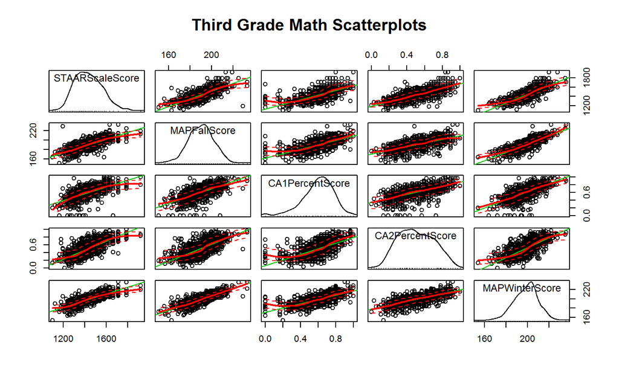

## R for Exploratory Data Analysis

Scatterplot matrix in psych:

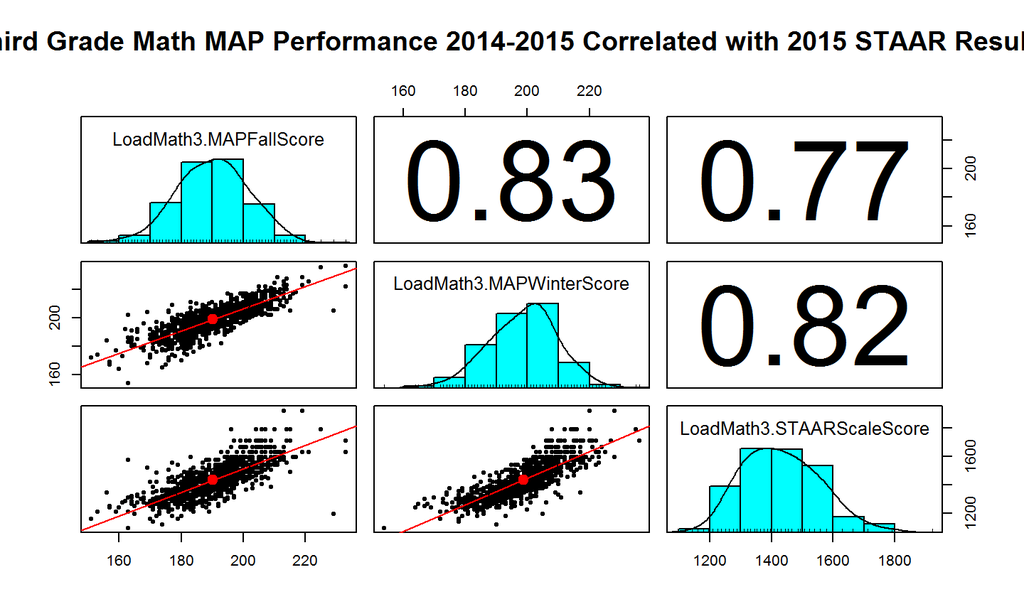

## R Markdown: R for Presentation and Reproducibility

We create monthly reports for the Uplift Board. Up until recently, whomever is tasked with it has to find what was previously done, compare, and then make updates. This is very time consuming.

We have started forays into producing some of the slides with R Markdown and creating Tufte-style documents.

We think the benefits of this will be resilency against the single point-of-failure problem we were previously experiencing.

## Hiring for R

- We have built into our hiring exercises the ability to complete them using R.
- Thus, this has allowed us to give candidates with R experience the chance to use it in their data analysis exercise.

## Connecting to Databases

library(RODBC)

- We use RODBC to connect to our databases, and pass SQL in order to pull back data sets into R
- Makes analyzing data a bit more seemless, and allows you to capture SQL within your R scripts

## Regex and String Matching

- External data requests for our program partners has required us to pull data without having primary keys available to do the pull.
- Thus, over the past two to three months, we had to start to learn and implement a non-manual process to identify data related to each other.
- We have been using grepl and sub functions to be able to do this.
- Soon we will start looking into fuzzy string matching, Python might work better for us.

## Our Ecosystem

- RStudio IDE
- dplyr
- tidyr
- car
- RODBC
- rmarkdown
  - pandoc
  - knitr
- psych
- zoo
- xlsx
- readxl

## Next Steps

- Running our R Scripts in SQL Server 2016 (currently preparing for an upgrade).
- Building Machine Learning Models using caret.
- Full adherance to *literate programming* and version control best practices.

## Lessons Learned

- The best way to learn any technolgy is to:
  - Use it daily
  - Teach it to others
- Provide your staff with the resources to learn it
  - R-bloggers has a lot of great vingettes
  - R Studio website
  - Coursera
  - Data Camp is excellent for the beginner
- Ask the to attend R related events
  - Like the Dallas R User Group!
  - SQL Saturday, Data Science Meetups

## Lessons Learned (con't)

- You need to provide time for your staff to use R
  - Start with code workshops where you work together
  - Need to allow people to make mistakes and iterate
  - If not, your staff will fall back on the tools they know the best
- Also teach them about how to find answers
  - Stackoverflow, Cross-Validation
  - How to google better (How to do [insert blank] in R)
  - GitHub (encourage them to create a GitHub account)

## Lessons Learned (con't)

- As your use of R grows, send your staff to UseR! when it is in the United States (it alternates between the US and oversees).
  - It is an inexpensive option that allows staff to quickly level up their skills.
  - The people there are amazing and will take time to help you if you ask them questions.
- Get your IT Department on board
  - IT Departments are warming up to the idea of open source software in the enterprise.
  - Approach them early with examples of other organizations using R to create buy-in.
  - Make sure there is a process for getting software installed on your organization's machines.

## Lessons Learned (con't)

- It has been difficult for us to keep everyone on the same version of R and same version of packages
  - Google apparently has figured this out, but we haven't
  - Better to anticipate that this might cause problems when running code and put in place a solution like packrat, than to be surprised by a method that no longer exists in a more recent version.
- Use R for what it is useful to you for, and don't try to use it to fix every problem
  - Embrace the tool, but if another tool does it better, use that tool!
  - Don't become the "I only use R" person, you are just an open source, command line saavy iteration of the "I only use Excel" person.

## References

*A Practitioner's Guide to Growth Models.* KE Castellano, AD Ho - Council of Chief State School Officers, 2013 - ERIC

## Q&A

My questions to the audience:

- How do you keep everyone in your organization on the same version of R and same version of the packages you use?
- What packages should we look to adpot, given our use cases?
- Any suggestions on how we can scale further?

## Thank you

- data@uplifteducation.org
- @UpliftDAT
- https://github.com/UpliftDAT